# Bunbury Offshore Wind Popwer Opportunity Assessment

Kelsea Dundon

2025-06-16

# Bunbury Offshore Wind Popwer Opportunity Assessment

## The Wind Resource

### Wind Data Sources

wind atlas Data modelled at 150 m

### Wind Data Analysis

#### Import data & Check for errors

- No NAN’s, NA’s or blank cells
- Max wind speed in data is 29.06 m/s, minimum is 0.2769
- In observational data wind speeds less than 0.5m/s may not be used in analysis, particularly if they are paired with directional data as the direction may not have been accurately recorded at such a low wind speed. However this is modelled data and directions are not included/will not be used so the data will be retained in the analysis.

```r
# Import and inspect the data
Wind_Data_Raw <- read.table('Wind_Data_Lat-33_Long+114.csv', header = TRUE, sep = ',', quote = "")
head(Wind_Data_Raw)
```

```
##           datetime wind_speed
## 1 01/01/1980 00:00      9.330
## 2 01/01/1980 01:00      9.020
## 3 01/01/1980 02:00      7.105
## 4 01/01/1980 03:00      6.680
## 5 01/01/1980 04:00      4.395
## 6 01/01/1980 05:00      4.330
```

From above we can see the data format is pretty simple, a datetime column and a windspeed.

```r
# Check for missing data in datetime column
is.nan(Wind_Data_Raw$datetime)["TRUE"]
```

```
## [1] NA
```

```r
is.na(Wind_Data_Raw$datetime)["TRUE"]
```

```
## [1] NA
```

```r
Wind_Data_Raw$datetime[""]
```

```
## [1] NA
```

```r
# Check for missing data in windspeed column, or for wind speeds less than 0.5m/s
is.nan(Wind_Data_Raw$wind_speed)["TRUE"]
```

```
## [1] NA
```

```r
is.na(Wind_Data_Raw$wind_speed)["TRUE"]
```

```
## [1] NA
```

```r
# Max and min wind speeds (will give an idea on if there is problematic data to be further investigated)
max(Wind_Data_Raw$wind_speed)
```

```
## [1] 29.06
```

```r
min(Wind_Data_Raw$wind_speed)
```

```
## [1] 0.2769
```

#### Data Preparation

I will add columns that will let me split out the data better; * Year, * month, * day of year, * hour of day, * season (Dec/Jan/Feb = Summer, Mar/Apr/May = Autumn, Jun/Jul/Aug = Winter, Sep/Oct/Nov = Spring )

```r
# Convert datetime to POSIXct format
Wind_Data_Raw$datetime <- as.POSIXct(Wind_Data_Raw$datetime, format = "%d/%m/%Y %H:%M", tz = "UTC")

# Create new columns for Date, Hour, Year, Month, Season
Wind_Data <- data.frame(Wind_Data_Raw[c(1:10000),])
Wind_Data$Date <- as.Date(Wind_Data$datetime)
Wind_Data$Hour <- hour(Wind_Data$datetime)
Wind_Data$Year <- year(Wind_Data$Date)
Wind_Data$Month <- month(Wind_Data$Date)

# Create a column for wind direction (data does not contain this but the bReeze package will need it)
Wind_Data$Dir <- 1

# Label seasons
indx <- setNames(rep(c("summer", "autumn", "winter", "spring"), each = 3), c(12, 1:11))
Wind_Data$Season <- unname(indx[as.character(Wind_Data$Month)])

head(Wind_Data)
```

```
##              datetime wind_speed       Date Hour Year Month Dir Season
## 1 1980-01-01 00:00:00      9.330 1980-01-01    0 1980     1   1 summer
## 2 1980-01-01 01:00:00      9.020 1980-01-01    1 1980     1   1 summer
## 3 1980-01-01 02:00:00      7.105 1980-01-01    2 1980     1   1 summer
## 4 1980-01-01 03:00:00      6.680 1980-01-01    3 1980     1   1 summer
## 5 1980-01-01 04:00:00      4.395 1980-01-01    4 1980     1   1 summer
## 6 1980-01-01 05:00:00      4.330 1980-01-01    5 1980     1   1 summer
```

```r
dim(Wind_Data)
```

```
## [1] 10000     8
```

#### Wind Characterisation

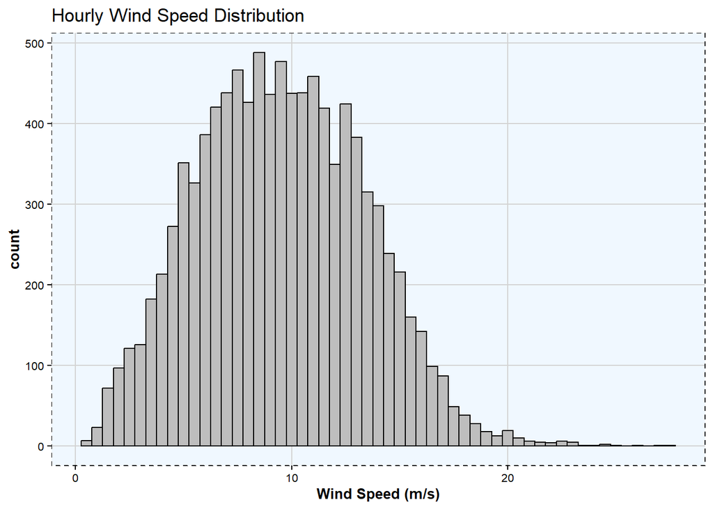

```r
# All data
ggplot(data = Wind_Data) +
  geom_histogram(mapping = aes(x=wind_speed), binwidth=0.5, color="black", fill="gray") +
  labs(title = 'Hourly Wind Speed Distribution') +
  xlab('Wind Speed (m/s)') +
  blue_theme()
```

```r
# Calculate the scale and shape factors from fitting a Weibull Distribution
fw <- fitdist(Wind_Data$wind_speed, "weibull")
summary(fw)
```

```
## Fitting of the distribution ' weibull ' by maximum likelihood
## Parameters :
##        estimate Std. Error
## shape  2.656177 0.02085792
## scale 10.713495 0.04243171
## Loglikelihood:  -27588.24   AIC:  55180.47   BIC:  55194.89
## Correlation matrix:
##           shape     scale
## shape 1.0000000 0.3103379
## scale 0.3103379 1.0000000
```

#### Seasonal Wind Variation

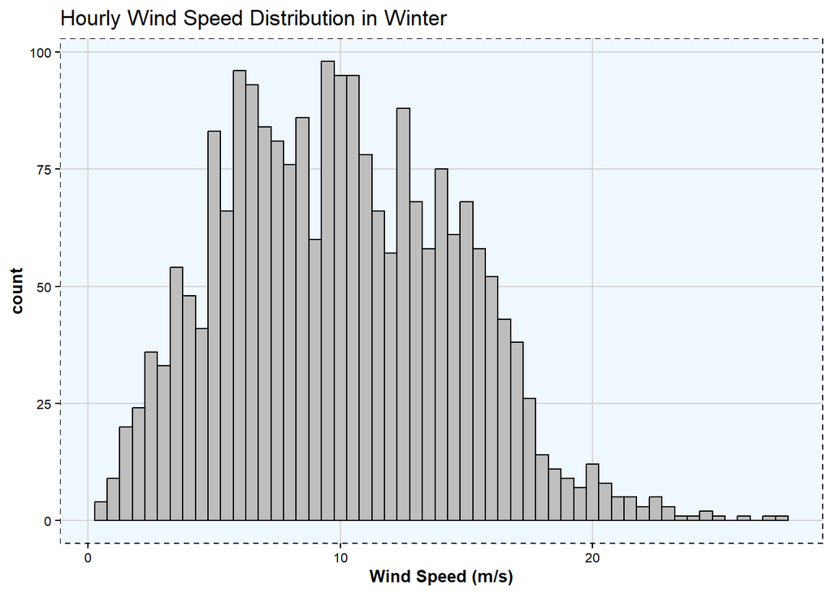

```r
# Separated by season
Wind_Winter <- Wind_Data[Wind_Data$Season == "winter", ]
ggplot(data = Wind_Winter) +
  geom_histogram(mapping = aes(x=wind_speed) , binwidth=0.5, color="black", fill="gray") +
  labs(title = 'Hourly Wind Speed Distribution in Winter') +
  xlab('Wind Speed (m/s)') +
  blue_theme()
```

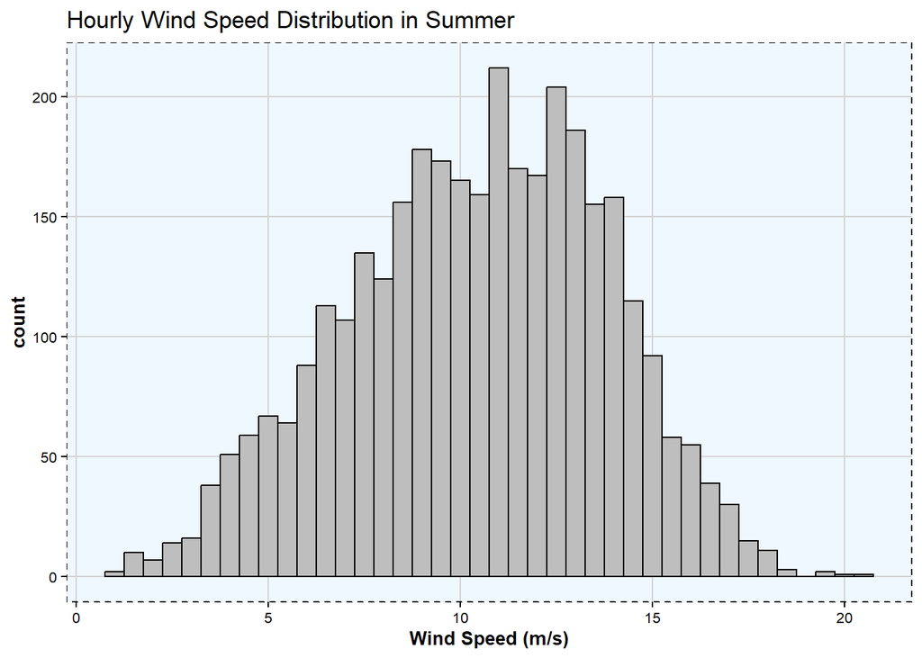

```r
Wind_Summer <- Wind_Data[Wind_Data$Season == "summer", ]
ggplot(data = Wind_Summer) +
  geom_histogram(mapping = aes(x=wind_speed) , binwidth=0.5, color="black", fill="gray") +
  labs(title = 'Hourly Wind Speed Distribution in Summer') +
  xlab('Wind Speed (m/s)') +
  blue_theme()
```

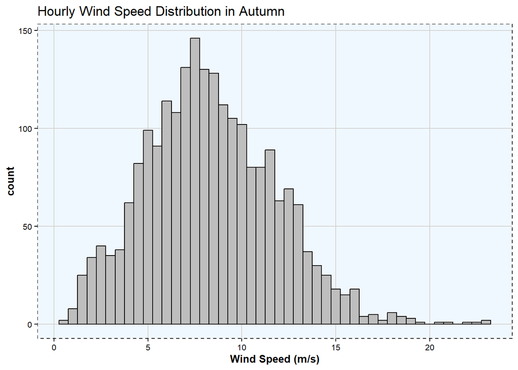

```r
Wind_Autumn <- Wind_Data[Wind_Data$Season == "autumn", ]
ggplot(data = Wind_Autumn) +
  geom_histogram(mapping = aes(x=wind_speed) , binwidth=0.5, color="black", fill="gray") +
  labs(title = 'Hourly Wind Speed Distribution in Autumn') +
  xlab('Wind Speed (m/s)') +
  blue_theme()
```

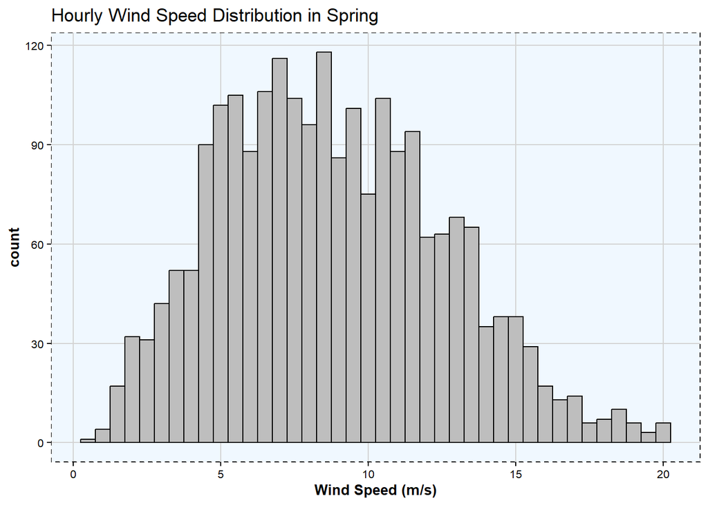

```r
Wind_Spring <- Wind_Data[Wind_Data$Season == "spring", ]
ggplot(data = Wind_Spring) +
  geom_histogram(mapping = aes(x=wind_speed) , binwidth=0.5, color="black", fill="gray") +
  labs(title = 'Hourly Wind Speed Distribution in Spring') +
  xlab('Wind Speed (m/s)') +
  blue_theme()
```

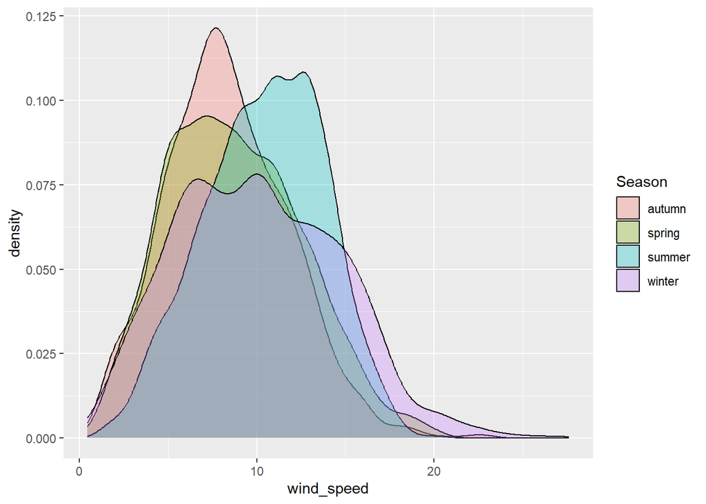

```r
# Lets show the seasonal differences
ggplot(data = Wind_Data) +
  geom_density(aes(x=wind_speed, fill=Season), alpha=0.3)
```

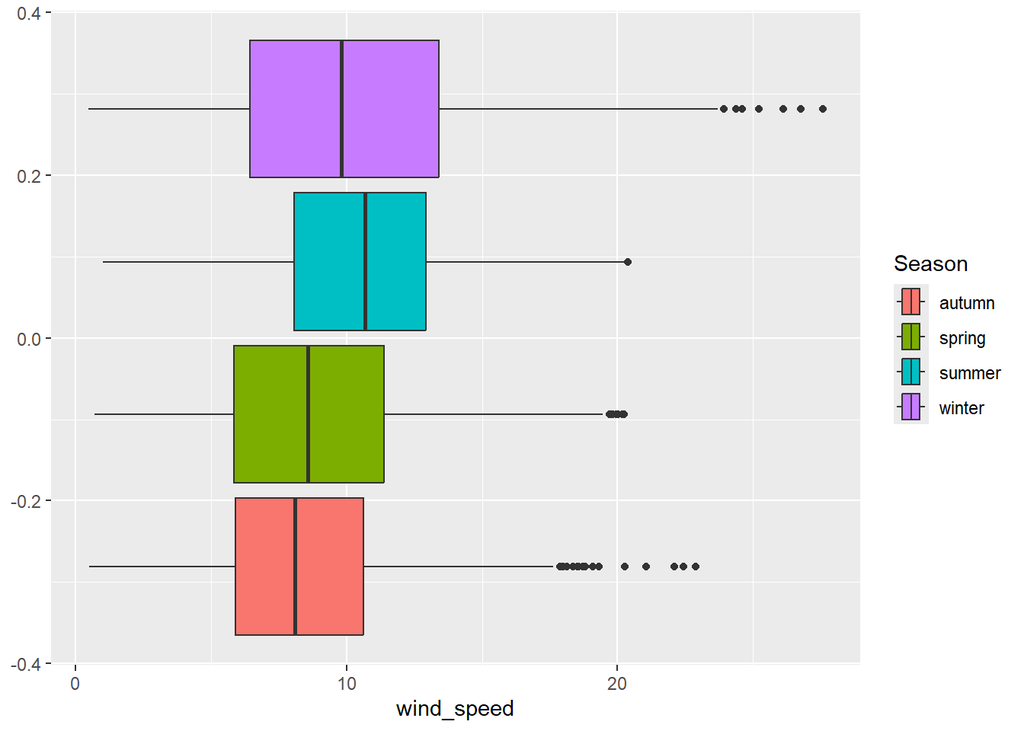

```r
ggplot(data = Wind_Data) +
  geom_boxplot(aes(x=wind_speed, fill=Season))
```

```r
# Fitting the Weibull Distribution to the seasonal data to see how the shape (a) and scale (k) factors vary
Data_summer <- subset(Wind_Data, Season == "summer")
fw_summer <- fitdist(Data_summer$wind_speed, "weibull")
summary(fw_summer)
```

```
## Fitting of the distribution ' weibull ' by maximum likelihood
## Parameters :
##        estimate Std. Error
## shape  3.513249 0.04834959
## scale 11.595657 0.05942847
## Loglikelihood:  -8922.764   AIC:  17849.53   BIC:  17861.79
## Correlation matrix:
##           shape     scale
## shape 1.0000000 0.3049604
## scale 0.3049604 1.0000000
```

```r
Data_winter <- subset(Wind_Data, Season == "winter")
fw_winter <- fitdist(Data_winter$wind_speed, "weibull")
summary(fw_winter)
```

```
## Fitting of the distribution ' weibull ' by maximum likelihood
## Parameters :
##        estimate Std. Error
## shape  2.336766 0.03931368
## scale 11.322901 0.10846164
## Loglikelihood:  -6434.667   AIC:  12873.33   BIC:  12884.73
## Correlation matrix:
##           shape     scale
## shape 1.0000000 0.3102086
## scale 0.3102086 1.0000000
```

```r
Data_spring <- subset(Wind_Data, Season == "spring")
fw_spring <- fitdist(Data_spring$wind_speed, "weibull")
summary(fw_spring)
```

```
## Fitting of the distribution ' weibull ' by maximum likelihood
## Parameters :
##       estimate Std. Error
## shape 2.500982 0.04189128
## scale 9.912355 0.08936531
## Loglikelihood:  -5946.464   AIC:  11896.93   BIC:  11908.31
## Correlation matrix:
##          shape    scale
## shape 1.000000 0.314876
## scale 0.314876 1.000000
```

```r
Data_autumn <- subset(Wind_Data, Season == "autumn")
fw_autumn <- fitdist(Data_autumn$wind_speed, "weibull")
summary(fw_autumn)
```

```
## Fitting of the distribution ' weibull ' by maximum likelihood
## Parameters :
##       estimate Std. Error
## shape 2.577957 0.04231066
## scale 9.392540 0.08164211
## Loglikelihood:  -5836.69   AIC:  11677.38   BIC:  11688.78
## Correlation matrix:
##           shape     scale
## shape 1.0000000 0.3132232
## scale 0.3132232 1.0000000
```

#### Diurnal Variation

```r
# Calculate the mean wind speed for each hour of the day in each season
Mean_hr_szn <- aggregate(data = Wind_Data, wind_speed ~ Season + Hour, mean)
print(Mean_hr_szn)
```

```
##    Season Hour wind_speed
## 1  autumn    0   8.038065
## 2  spring    0   8.239407
## 3  summer    0   9.584366
## 4  winter    0  10.368728
## 5  autumn    1   7.967467
## 6  spring    1   8.157791
## 7  summer    1   9.362577
## 8  winter    1  10.332380
## 9  autumn    2   7.528250
## 10 spring    2   7.759154
## 11 summer    2   8.260338
## 12 winter    2  10.123522
## 13 autumn    3   7.459196
## 14 spring    3   7.727824
```

[output cut: 82 more lines]

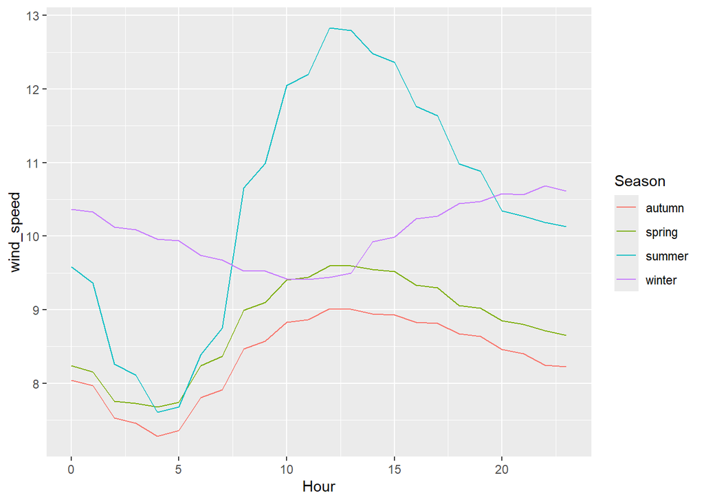

```r
#Can now join into the existing dataframe, or just use seperately for this graph
# Graph together
ggplot(data = Mean_hr_szn) +
  geom_line(aes(x=Hour, y=wind_speed, color=Season))
```

#### Synoptic Variations

These variations occur on the multi-day scale and are usually associated with weather formations, they are less predictable from historical data, but the use of data with meteorological forecasting can significantly increase predictability. Of use at this stage of analysis is an understanding of the frequency of the variations (i.e. on average are most weather formations 3 days, 5 days, 14 day events). The data source currently being used does not contain direction data, which will make changes associated with large weather formations difficult to identify. It is recommended that this analysis is done on another data source and so it will be ommitted at this stage.

#### Power Density

Apply Betz limit Assume a standard air density of 1.225 kg/m³

```r
p <- 1.225
Cpmax = 16/27
Um = mean(Wind_Data$wind_speed)
Um
```

```
## [1] 9.523299
```

```r
Um_summer = mean(Data_summer$wind_speed)
Um_summer
```

```
## [1] 10.42996
```

```r
Um_winter = mean(Data_winter$wind_speed)
Um_winter
```

```
## [1] 10.03511
```

```r
Um_spring = mean(Data_spring$wind_speed)
Um_spring
```

```
## [1] 8.785341
```

```r
Um_autumn = mean(Data_autumn$wind_speed)
Um_autumn
```

```
## [1] 8.345293
```

```r
# Wind Power Density (W/m^2)
Pideal = (1/2) * p * Um^3
Pideal
```

```
## [1] 529.0154
```

```r
# Maximum Power Density Available (W/m^2)
Pmax = Cpmax * Pideal
Pmax
```

```
## [1] 313.4906
```

## Turbine Power Curves

The bReeze package contains many power curves in .wtg and .pow formats.

```r
# Pulling out all of the power-curves within bReeze
bReeze_files <- list.files(system.file(package = 'bReeze'), recursive = T, full.names = T)
# This generated a list of all the files, now I'll exclude those that are not power curve file names. PC files start from line 23 and end on 115
pc_files1 <- bReeze_files[c(23:115)]
pc_files2 <- substr(pc_files1, 67,100 )
pc_files2
```

```
##  [1] "Bonus_82.4m_2.3MW.pow"         "Bonus_MKIV_600kW.pow"
##  [3] "Clipper_LibertyC100_2.5MW.pow" "Clipper_LibertyC89_2.5MW.pow"
##  [5] "Clipper_LibertyC93_2.5MW.pow"  "Clipper_LibertyC96_2.5MW.pow"
##  [7] "Enercon_E101_3.0MW.pow"        "Enercon_E126_7.5MW.pow"
##  [9] "Enercon_E33_330kW.pow"         "Enercon_E40_500kW.pow"
## [11] "Enercon_E44_900kW.pow"         "Enercon_E48_800kW.pow"
## [13] "Enercon_E53_800kW.pow"         "Enercon_E66_1870kW.pow"
## [15] "Enercon_E66_2000kW.pow"        "Enercon_E70_2.3MW.pow"
## [17] "Enercon_E82_2.0MW.pow"         "Enercon_E82_2.3MW.pow"
## [19] "Enercon_E82_3.0MW.pow"         "EWT_DW52_500kW.pow"
## [21] "EWT_DW54_500kW.pow"            "EWT_DW90_2MW.pow"
## [23] "EWT_DW96_2MW.pow"              "Gamesa_G52_850kW.pow"
## [25] "Gamesa_G58_850kW.pow"          "Gamesa_G80_2.0MW.pow"
## [27] "Gamesa_G83_2.0MW.pow"          "Gamesa_G87_2.0MW.pow"
## [29] "Gamesa_G90_2.0MW.pow"          "GE_1.5sl_1.5MW.pow"
```

[output cut: 32 more lines]

For this analysis offshore turbines will be used, the first list below is commercially available/installed turbines, the second list is protoype turbines (some of which are being installed in wind farms currently under construction, and the third is concept offshore turbines.For currently installed turbines the list has been refined to only wind farms commissioned after 2020 to exclude turbines that have been superseded by the advance in technology.

### Commercially used:

MHI Vestas V164-9.5 MW MHI Vestas V174-9.5 MW MHI Vestas V164-10 MW Vestas V236-15MW Siemens Gamesa SG-14-222 DD 14.7MW Siemens Gamesa SWT-4.0-146 Siemens Gamesa SWT-7.0-154 Siemens Gamesa SG 8.0-167 DD Siemens Gamesa SWT-8.4-167 Siemens Gamesa 11.0-200 DD Siemens Gamesa SG 14-236 DD Siemens Gamesa 14-222 DD GE Haliade 150-6MW GE Wind Energy Haliade-X 13MW or 13.6MW Mingyang Wind Power MySE 12-242 12MW Mingyang MY-5.5 MW MingYang MySE5.5-155 Mingyang MySE6.45-180 CSIC Haizhuang H220-8.35 MySE6.8-158 MySE8.3-180

### Prototypes:

Siemens Gamesa SG DD-276 21.5MW Mingyang Wind Power MySE18.X-20MW 18.X to 20MW Dongfang Electric DEW-18MW-260 18MW Mingyang Wind Power MySE16.0-260 16MW Goldwind GWH252 16MW GE Wind Energy Haliade-X 14.7

### Concept Designs:

Dongfang Electric DEW-26MW-310 Mingyang Wind Power MySE22MW CSSC Haizhuang H260-18MW

### Power Curves for Analysis

However most of the turbines listed above, especially the newer and more powerful turbines do not have power curves in the bReeze package, and they are not freely available online. So that this analysis can progress, and consider a range of turbines, all turbines rated 3MW or above from bReeze will be used. “Enercon_E101_3.0MW.pow” “Enercon_E126_7.5MW.pow” “Enercon_E82_3.0MW.pow” “Vestas_V164_7.0MW_os.pow”  
“Vestas_V90_3.0MW.pow”  
“Vestas_V112_3MW.pow” “Leitwind_LTW101_3.0MW.pow” “Repower_5M_5.0MW.pow” “Siemens_SWT-3.6MW-107m.pow” “Siemens_SWT-3.6MW-120m.pow”

```r
PC_File <- c("Enercon_E101_3.0MW.pow", "Enercon_E126_7.5MW.pow", "Enercon_E82_3.0MW.pow", "Vestas_V164_7.0MW_os.pow", "Vestas_V90_3.0MW.pow", "Vestas_V112_3MW.pow", "Leitwind_LTW101_3.0MW.pow", "Repower_5M_5.0MW.pow", "Siemens_SWT-3.6MW-107m.pow", "Siemens_SWT-3.6MW-120m.pow")

# Additional data for the analysis has been sourced from thewindpower.net
Power_Curves <- as.data.frame(PC_File)
Power_Curves$HH_min_m <- c(99,135,59,105,99,84,95,95,80,88)
Power_Curves$HH_max_m <- c(149,135,84,150,149,119,143,117,96,90)
Power_Curves$Rated_Power_MW <- c(3.0,7.5,3.0,7.0,3.05,3.0,3.0,5.08,3.6,3.6)
Power_Curves$Rotor_Dia_m <- c(101,127,82,164,101,112,100.9,126.5,107,120)
Power_Curves$Cutin_speed_ms <- c(2,2.5,2,4,2,3.5,2.7,3.5,3.5,3.5)
Power_Curves$Rated_speed_ms <- c(13,17,17,11,13,15.5,15,14,16.5,12)
Power_Curves$Cutout_speed_ms <- c(25,25,25,25,25,25,25,30,25,25)
Power_Curves$Offshore <- c("no","no","no","yes","no","no","no","yes","yes","yes")
head(Power_Curves)
```

```
##                    PC_File HH_min_m HH_max_m Rated_Power_MW Rotor_Dia_m
## 1   Enercon_E101_3.0MW.pow       99      149           3.00         101
## 2   Enercon_E126_7.5MW.pow      135      135           7.50         127
## 3    Enercon_E82_3.0MW.pow       59       84           3.00          82
## 4 Vestas_V164_7.0MW_os.pow      105      150           7.00         164
## 5     Vestas_V90_3.0MW.pow       99      149           3.05         101
## 6      Vestas_V112_3MW.pow       84      119           3.00         112
##   Cutin_speed_ms Rated_speed_ms Cutout_speed_ms Offshore
## 1            2.0           13.0              25       no
## 2            2.5           17.0              25       no
## 3            2.0           17.0              25       no
## 4            4.0           11.0              25      yes
## 5            2.0           13.0              25       no
## 6            3.5           15.5              25       no
```

## Wind Power Generation Estimates

Power curves are ready to apply, now the wind data needs to be set-up into the format required by bReeze.

```r
# Convert POSIXct to POSIXlt
Wind_Data$datetime_lt <- as.POSIXlt(Wind_Data$datetime)

# Ensure wind_speed is numeric (just in case)
Wind_Data$wind_speed <- as.numeric(Wind_Data$wind_speed)

# Check set-up before forming set
length(Wind_Data$datetime_lt) == length(Wind_Data$wind_speed)
```

```
## [1] TRUE
```

```r
is.na(Wind_Data$datetime_lt)["TRUE"]
```

```
## [1] NA
```

```r
is.na(Wind_Data$wind_speed)["TRUE"]
```

```
## [1] NA
```

```r
is.numeric(Wind_Data$wind_speed)
```

```
## [1] TRUE
```

```r
range(Wind_Data$datetime_lt)
```

```
## [1] "1980-01-01 00:00:00 UTC" "1981-02-20 15:00:00 UTC"
```

```r
# Create placeholders with NAs for missing fields
n <- nrow(Wind_Data)

# Set 'n' to exact number of rows
n <- nrow(Wind_Data)

# Check for any unexpected NA
sum(is.na(Wind_Data$wind_speed))   # Should be 0 ideally
```

```
## [1] 0
```

```r
sum(is.na(Wind_Data$datetime_lt))  # Should be 0 ideally
```

```
## [1] 0
```

```r
# Build the set
Wind_Data_set <- set(
  height = 150,
  v.avg = Wind_Data$wind_speed,
  dir.avg = Wind_Data$Dir
)

# Create mast object with POSIXlt timestamp
Wind_Data_mast <- mast(timestamp = Wind_Data$datetime_lt, set = Wind_Data_set, loc = NULL, desc = "Modelled data 150m")

# Check output
Wind_Data_mast
```

```
##
##  Met mast
##
## description: Modelled data 150m
##
## measuring period: from 1980-01-01 to 1981-02-20 15:00:00 (416.6 days)
## samples: 10000
##
## datasets (1):
##     height wind speed availability
##        [m]      [m/s]          [%]
## set    150       9.52          100
##
## signals (2):
##         set
## v.avg     o
## dir.avg   o
##  (o=original data, c=cleaned data)
```

```r
# calculate wind profile
pf <-  windprofile(mast = Wind_Data_mast, v.set = 1, dir.set=1, num.sectors=12, method=c("hellman", "loglm", "fixed"), alpha=NULL, digits=1, print=TRUE)
```

```
##
##  Wind profile
##
##     alpha wind speed
##       [-]      [m/s]
## N     0.2        9.5
## NNE   0.2        NaN
## ENE   0.2        NaN
## E     0.2        NaN
## ESE   0.2        NaN
## SSE   0.2        NaN
## S     0.2        NaN
## SSW   0.2        NaN
## WSW   0.2        NaN
## W     0.2        NaN
## WNW   0.2        NaN
## NNW   0.2        NaN
## all   0.2        9.5
##
## reference height: 150 m
##
## call: windprofile(mast=Wind_Data_mast, v.set=1, dir.set=1, num.sectors=12, method="fixed", alpha=c(0.2, 0.2, 0.2, 0.2, 0.2, 0.2, 0.2, 0.2, 0.2, 0.2, 0.2, 0.2), subset=NA, digits=1, print=TRUE)
```

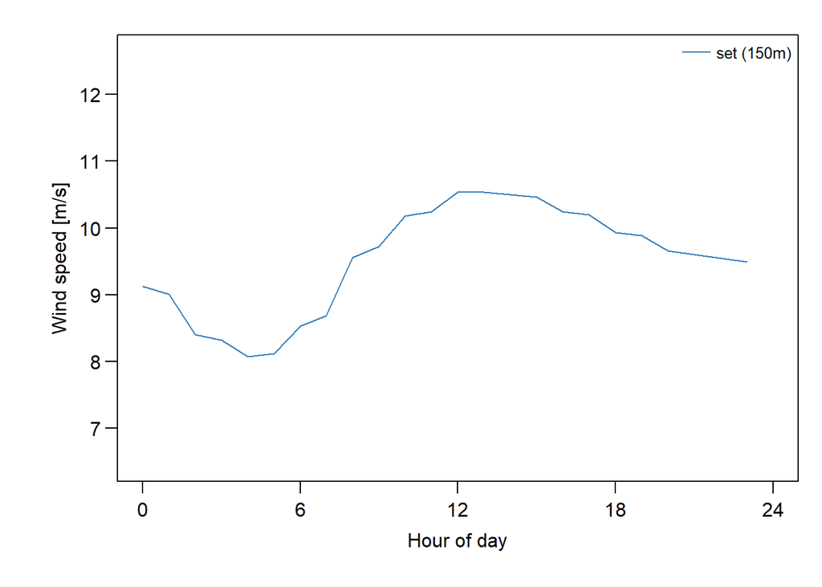

```r
day.plot(mast = Wind_Data_mast, set = 1, dir.set = 1, signal = "v.avg")
```

### Evaluation Areas Now the wind data is prepared we can apply the power curves. I will be looking at the following for each;

- Annual Energy Production
- Capacity Factor
- How does the mean wind speed align with the rated wind speed
- Energy production over an average day per year/season

#### Enercon E101

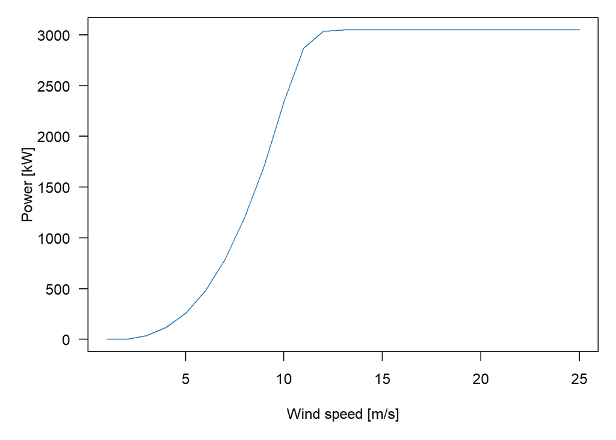

```r
# Power curve
pc_1 <- pc(Power_Curves$PC_File[1])
plot(pc_1, cp=TRUE, ct=TRUE)
```

```r
# Hub Height min & max
hh1_min <- Power_Curves$HH_min_m[1]
hh1_max <- Power_Curves$HH_max_m[1]

# calculate annual energy production with minimum hub height
aep_1_hhmin <- aep(profile = pf, pc = pc_1, hub.h = hh1_min)
```

```
##
##  Annual energy production
##
##       wind speed operation   total     0-5    5-10   10-15   15-20     >20
##            [m/s]     [h/a] [MWh/a] [MWh/a] [MWh/a] [MWh/a] [MWh/a] [MWh/a]
## N          8.764      8760   14077     133    4870    7828    1209      36
## NNE
## ENE
## E
## ESE
## SSE
## S
## SSW
## WSW
## W
## WNW
## NNW
## total      8.764      8760   14077     133    4870    7828    1209      36
##
## capacity factor: 0.527
##
## call: aep(profile=pf, pc=pc_1, hub.h=99, rho=1.225, avail=1, bins=c(0, 5, 10, 15, 20), sectoral=FALSE, digits=c(3, 0, 0, 3), print=TRUE)
```

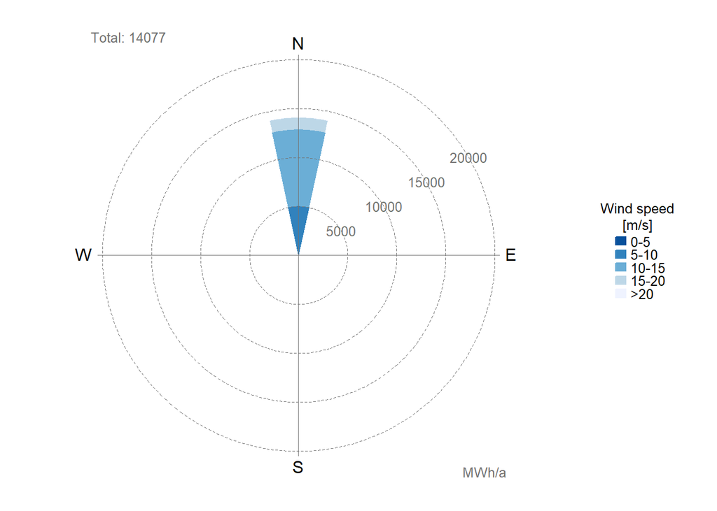

```r
capacity_1_hhmin <- aep_1_hhmin$capacity
AEP_Plot_1_hhmin <- plot(aep_1_hhmin)
```

```r
# calculate annual energy production with maximum hub height
aep_1_hhmax <- aep(profile = pf, pc = pc_1, hub.h = hh1_max)
```

```
##
##  Annual energy production
##
##       wind speed operation   total     0-5    5-10   10-15   15-20     >20
##            [m/s]     [h/a] [MWh/a] [MWh/a] [MWh/a] [MWh/a] [MWh/a] [MWh/a]
## N          9.511      8760   15775     109    4464    8929    2141     133
## NNE
## ENE
## E
## ESE
## SSE
## S
## SSW
## WSW
## W
## WNW
## NNW
## total      9.511      8760   15775     109    4464    8929    2141     133
##
## capacity factor: 0.59
##
## call: aep(profile=pf, pc=pc_1, hub.h=149, rho=1.225, avail=1, bins=c(0, 5, 10, 15, 20), sectoral=FALSE, digits=c(3, 0, 0, 3), print=TRUE)
```

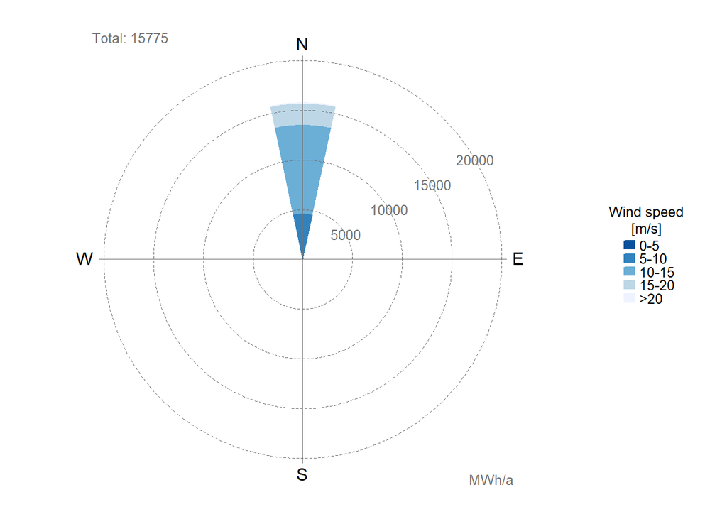

```r
capacity_1_hhmax <- aep_1_hhmax$capacity
AEP_Plot_1_hhmax <- plot(aep_1_hhmax)
```

```r
# plot energy production over typical day
```

#### Enercon E126

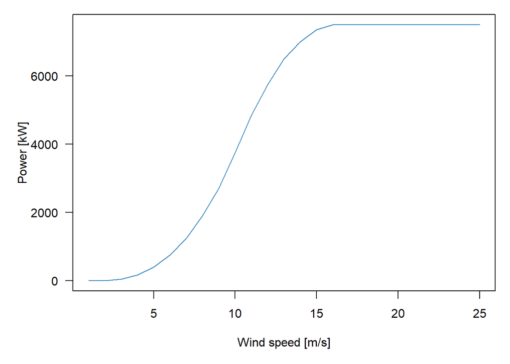

```r
# Power curve
pc_2 <- pc(Power_Curves$PC_File[2])
plot(pc_2, cp=TRUE, ct=TRUE)
```

```r
# Hub Height min & max
hh2_min <- Power_Curves$HH_min_m[2]
hh2_max <- Power_Curves$HH_max_m[2]

# calculate annual energy production with minimum hub height
aep_2_hhmin <- aep(profile = pf, pc = pc_2, hub.h = hh2_min)
```

```
##
##  Annual energy production
##
##       wind speed operation   total     0-5    5-10   10-15   15-20     >20
##            [m/s]     [h/a] [MWh/a] [MWh/a] [MWh/a] [MWh/a] [MWh/a] [MWh/a]
## N          9.325      8760   29181     175    7237   16888    4636     245
## NNE
## ENE
## E
## ESE
## SSE
## S
## SSW
## WSW
## W
## WNW
## NNW
## total      9.325      8760   29181     175    7237   16888    4636     245
##
## capacity factor: 0.444
##
## call: aep(profile=pf, pc=pc_2, hub.h=135, rho=1.225, avail=1, bins=c(0, 5, 10, 15, 20), sectoral=FALSE, digits=c(3, 0, 0, 3), print=TRUE)
```

```r
capacity_2_hhmin <- aep_2_hhmin$capacity
AEP_Plot_2_hhmin <- plot(aep_2_hhmin)

# calculate annual energy production with maximum hub height
aep_2_hhmax <- aep(profile = pf, pc = pc_2, hub.h = hh2_max)
```

[output not shown]

```
##
##  Annual energy production
##
##       wind speed operation   total     0-5    5-10   10-15   15-20     >20
##            [m/s]     [h/a] [MWh/a] [MWh/a] [MWh/a] [MWh/a] [MWh/a] [MWh/a]
## N          9.325      8760   29181     175    7237   16888    4636     245
## NNE
## ENE
## E
## ESE
## SSE
## S
## SSW
## WSW
## W
## WNW
## NNW
## total      9.325      8760   29181     175    7237   16888    4636     245
##
## capacity factor: 0.444
##
## call: aep(profile=pf, pc=pc_2, hub.h=135, rho=1.225, avail=1, bins=c(0, 5, 10, 15, 20), sectoral=FALSE, digits=c(3, 0, 0, 3), print=TRUE)
```

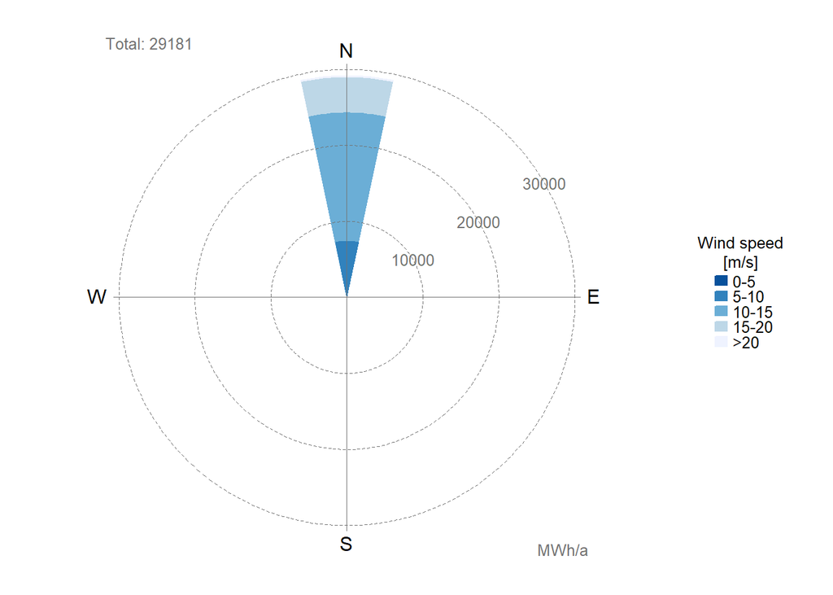

```r
capacity_2_hhmax <- aep_2_hhmax$capacity
AEP_Plot_2_hhmax <- plot(aep_2_hhmax)
```

```r
# plot energy production over typical day
```

#### Enercon E82

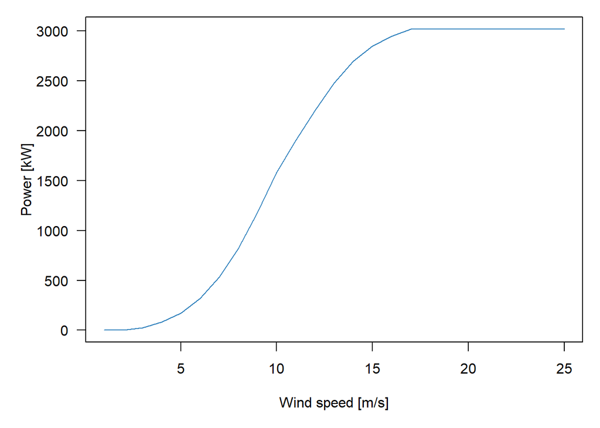

```r
# Power curve
pc_3 <- pc(Power_Curves$PC_File[3])
plot(pc_3, cp=TRUE, ct=TRUE)
```

```r
# Hub Height min & max
hh3_min <- Power_Curves$HH_min_m[3]
hh3_max <- Power_Curves$HH_max_m[3]

# calculate annual energy production with minimum hub height
aep_3_hhmin <- aep(profile = pf, pc = pc_3, hub.h = hh3_min)
```

```
##
##  Annual energy production
##
##       wind speed operation   total     0-5    5-10   10-15   15-20     >20
##            [m/s]     [h/a] [MWh/a] [MWh/a] [MWh/a] [MWh/a] [MWh/a] [MWh/a]
## N          7.902      8760    8507     116    3551    4387     449       4
## NNE
## ENE
## E
## ESE
## SSE
## S
## SSW
## WSW
## W
## WNW
## NNW
## total      7.902      8760    8507     116    3551    4387     449       4
##
## capacity factor: 0.322
##
## call: aep(profile=pf, pc=pc_3, hub.h=59, rho=1.225, avail=1, bins=c(0, 5, 10, 15, 20), sectoral=FALSE, digits=c(3, 0, 0, 3), print=TRUE)
```

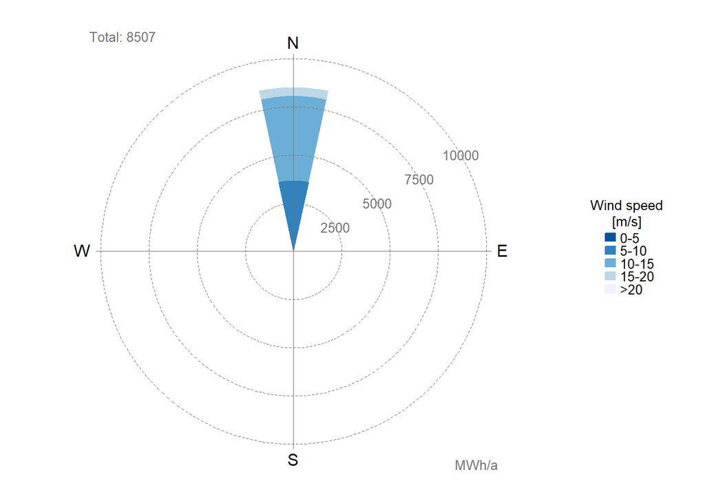

```r
capacity_3_hhmin <- aep_3_hhmin$capacity
AEP_Plot_3_hhmin <- plot(aep_3_hhmin)
```

```r
# calculate annual energy production with maximum hub height
aep_3_hhmax <- aep(profile = pf, pc = pc_3, hub.h = hh3_max)
```

```
##
##  Annual energy production
##
##       wind speed operation   total     0-5    5-10   10-15   15-20     >20
##            [m/s]     [h/a] [MWh/a] [MWh/a] [MWh/a] [MWh/a] [MWh/a] [MWh/a]
## N          8.481      8760    9832      99    3411    5411     892      20
## NNE
## ENE
## E
## ESE
## SSE
## S
## SSW
## WSW
## W
## WNW
## NNW
## total      8.481      8760    9832      99    3411    5411     892      20
##
## capacity factor: 0.372
##
## call: aep(profile=pf, pc=pc_3, hub.h=84, rho=1.225, avail=1, bins=c(0, 5, 10, 15, 20), sectoral=FALSE, digits=c(3, 0, 0, 3), print=TRUE)
```

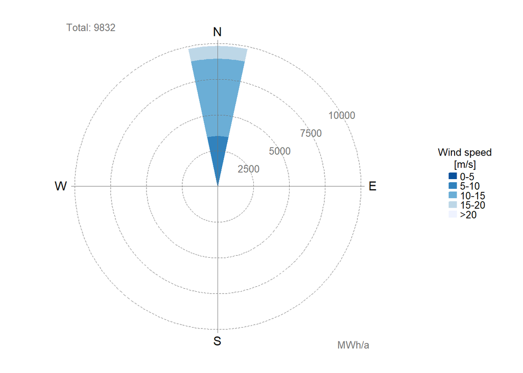

```r
capacity_3_hhmax <- aep_3_hhmax$capacity
AEP_Plot_3_hhmax <- plot(aep_3_hhmax)
```

```r
# plot energy production over typical day
```

#### Vestas V164

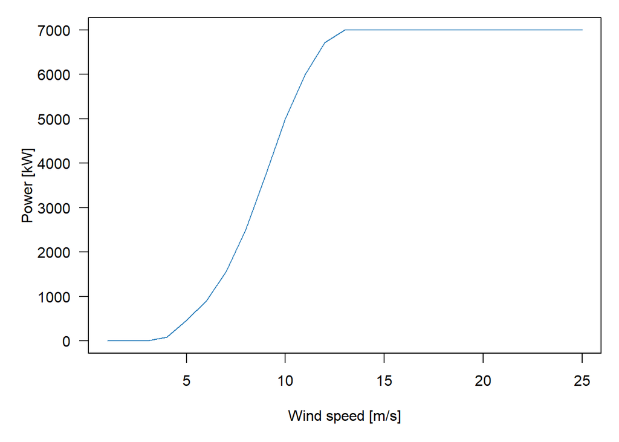

```r
# Power curve
pc_4 <- pc(Power_Curves$PC_File[4])
plot(pc_4, cp=TRUE, ct=TRUE)
```

```r
# Hub Height min & max
hh4_min <- Power_Curves$HH_min_m[4]
hh4_max <- Power_Curves$HH_max_m[4]

# calculate annual energy production with minimum hub height
aep_4_hhmin <- aep(profile = pf, pc = pc_4, hub.h = hh4_min)
```

```
##
##  Annual energy production
##
##       wind speed operation   total     0-5    5-10   10-15   15-20     >20
##            [m/s]     [h/a] [MWh/a] [MWh/a] [MWh/a] [MWh/a] [MWh/a] [MWh/a]
## N          8.868      8760   31005     150   10110   17602    3041     102
## NNE
## ENE
## E
## ESE
## SSE
## S
## SSW
## WSW
## W
## WNW
## NNW
## total      8.868      8760   31005     150   10110   17602    3041     102
##
## capacity factor: 0.506
##
## call: aep(profile=pf, pc=pc_4, hub.h=105, rho=1.225, avail=1, bins=c(0, 5, 10, 15, 20), sectoral=FALSE, digits=c(3, 0, 0, 3), print=TRUE)
```

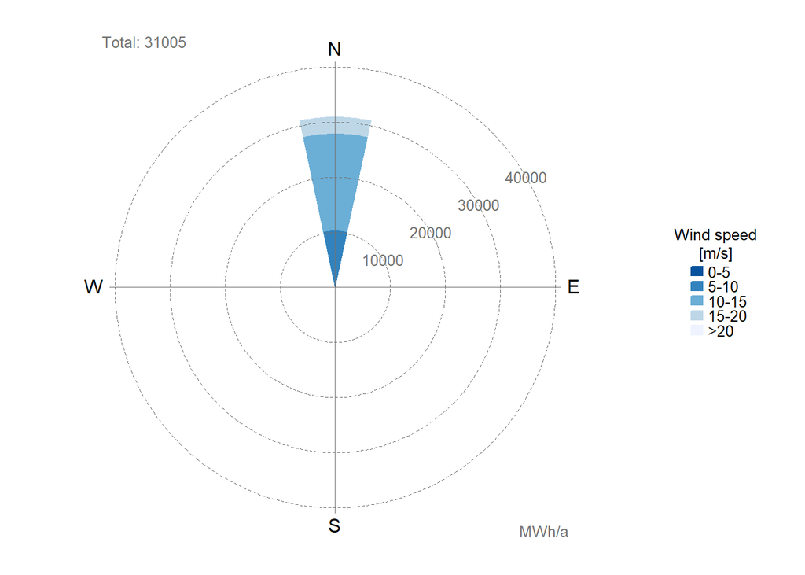

```r
capacity_4_hhmin <- aep_4_hhmin$capacity
AEP_Plot_4_hhmin <- plot(aep_4_hhmin)
```

```r
# calculate annual energy production with maximum hub height
aep_4_hhmax <- aep(profile = pf, pc = pc_4, hub.h = hh4_max)
```

```
##
##  Annual energy production
##
##       wind speed operation   total     0-5    5-10   10-15   15-20     >20
##            [m/s]     [h/a] [MWh/a] [MWh/a] [MWh/a] [MWh/a] [MWh/a] [MWh/a]
## N          9.523      8760   34470     127    9367   19713    4953     310
## NNE
## ENE
## E
## ESE
## SSE
## S
## SSW
## WSW
## W
## WNW
## NNW
## total      9.523      8760   34470     127    9367   19713    4953     310
##
## capacity factor: 0.562
##
## call: aep(profile=pf, pc=pc_4, hub.h=150, rho=1.225, avail=1, bins=c(0, 5, 10, 15, 20), sectoral=FALSE, digits=c(3, 0, 0, 3), print=TRUE)
```

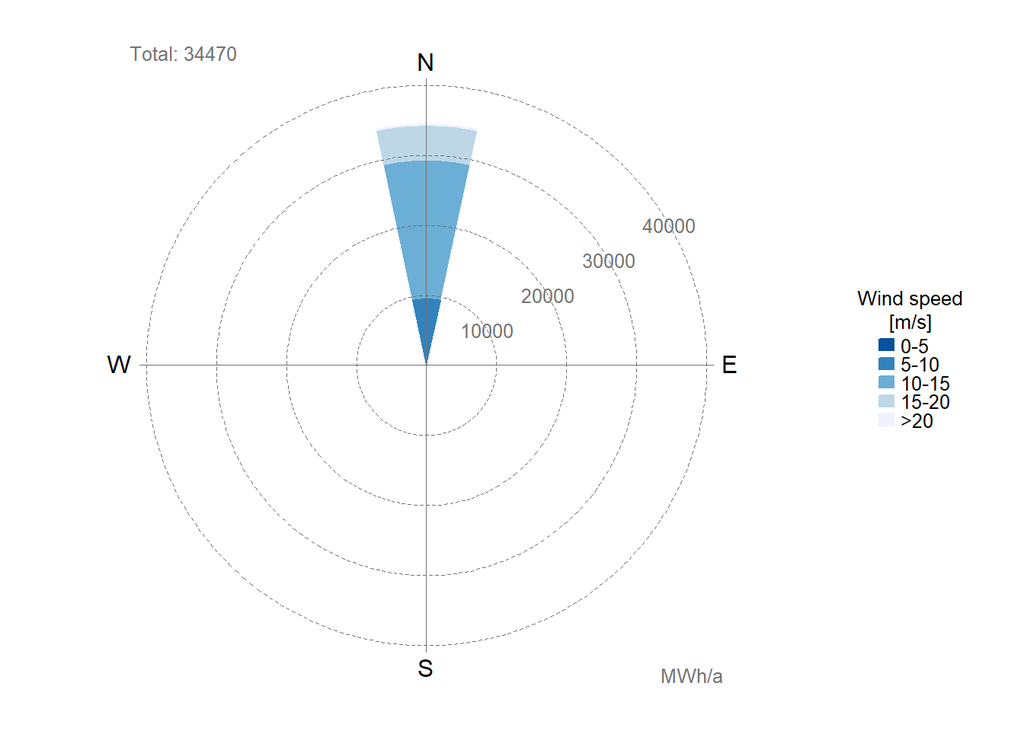

```r
capacity_4_hhmax <- aep_4_hhmax$capacity
AEP_Plot_4_hhmax <- plot(aep_4_hhmax)
```

```r
# plot energy production over typical day
```

#### Vestas V90

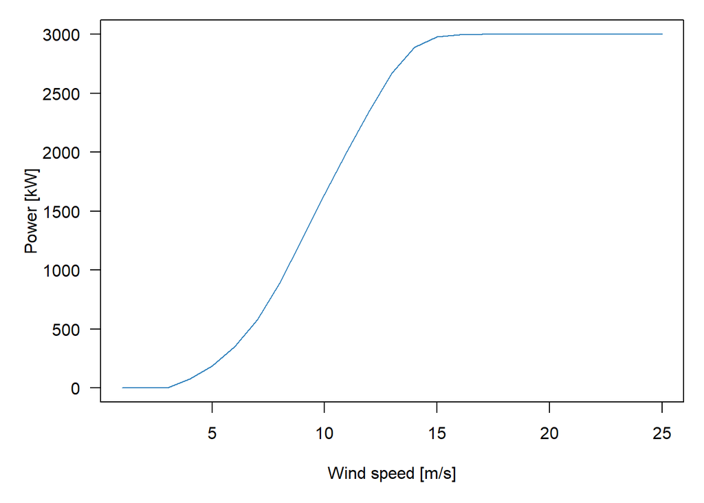

```r
# Power curve
pc_5 <- pc(Power_Curves$PC_File[5])
plot(pc_5, cp=TRUE, ct=TRUE)
```

```r
# Hub Height min & max
hh5_min <- Power_Curves$HH_min_m[5]
hh5_max <- Power_Curves$HH_max_m[5]

# calculate annual energy production with minimum hub height
aep_5_hhmin <- aep(profile = pf, pc = pc_5, hub.h = hh5_min)
```

```
##
##  Annual energy production
##
##       wind speed operation   total     0-5    5-10   10-15   15-20     >20
##            [m/s]     [h/a] [MWh/a] [MWh/a] [MWh/a] [MWh/a] [MWh/a] [MWh/a]
## N          8.764      8760   11082      86    3560    6213    1188      36
## NNE
## ENE
## E
## ESE
## SSE
## S
## SSW
## WSW
## W
## WNW
## NNW
## total      8.764      8760   11082      86    3560    6213    1188      36
##
## capacity factor: 0.422
##
## call: aep(profile=pf, pc=pc_5, hub.h=99, rho=1.225, avail=1, bins=c(0, 5, 10, 15, 20), sectoral=FALSE, digits=c(3, 0, 0, 3), print=TRUE)
```

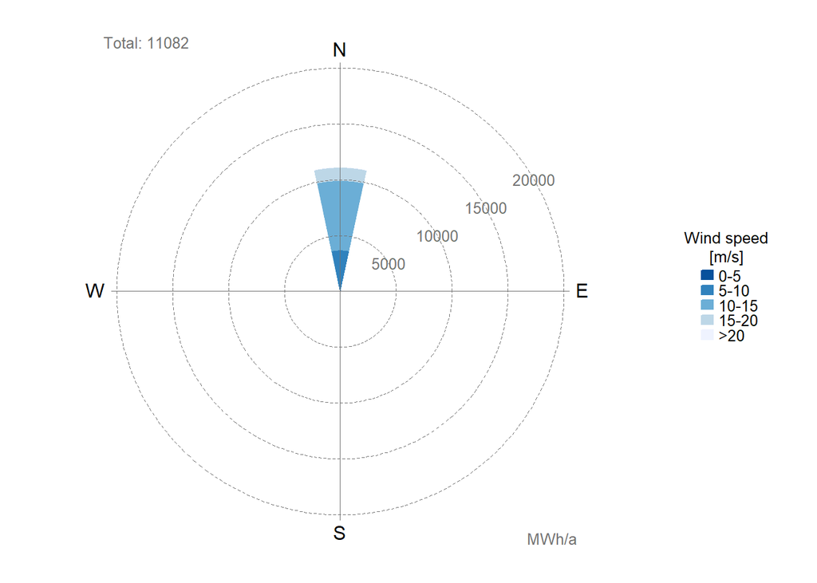

```r
capacity_5_hhmin <- aep_5_hhmin$capacity
AEP_Plot_5_hhmin <- plot(aep_5_hhmin)
```

```r
# calculate annual energy production with maximum hub height
aep_5_hhmax <- aep(profile = pf, pc = pc_5, hub.h = hh5_max)
```

```
##
##  Annual energy production
##
##       wind speed operation   total     0-5    5-10   10-15   15-20     >20
##            [m/s]     [h/a] [MWh/a] [MWh/a] [MWh/a] [MWh/a] [MWh/a] [MWh/a]
## N          9.511      8760   12743      70    3262    7177    2103     130
## NNE
## ENE
## E
## ESE
## SSE
## S
## SSW
## WSW
## W
## WNW
## NNW
## total      9.511      8760   12743      70    3262    7177    2103     130
##
## capacity factor: 0.485
##
## call: aep(profile=pf, pc=pc_5, hub.h=149, rho=1.225, avail=1, bins=c(0, 5, 10, 15, 20), sectoral=FALSE, digits=c(3, 0, 0, 3), print=TRUE)
```

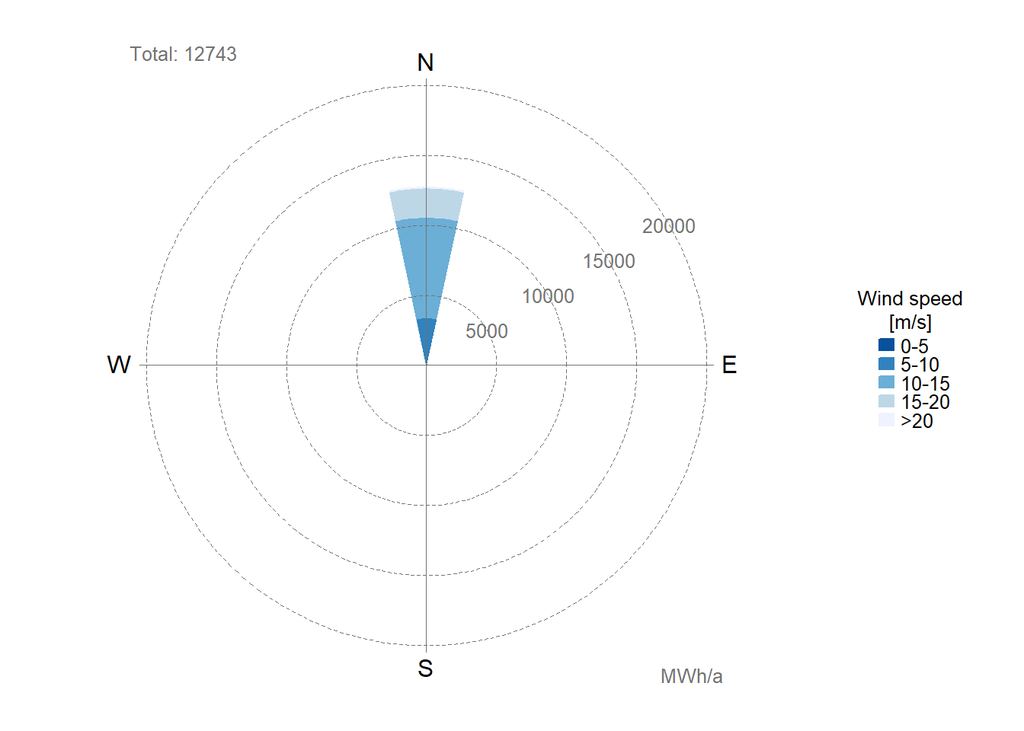

```r
capacity_5_hhmax <- aep_5_hhmax$capacity
AEP_Plot_5_hhmax <- plot(aep_5_hhmax)
```

```r
# plot energy production over typical day
```

#### Vestas V112

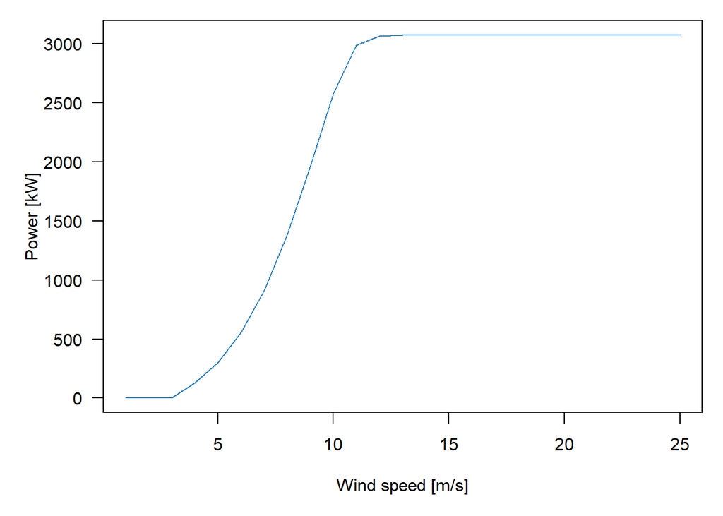

```r
# Power curve
pc_6 <- pc(Power_Curves$PC_File[6])
plot(pc_6, cp=TRUE, ct=TRUE)
```

```r
# Hub Height min & max
hh6_min <- Power_Curves$HH_min_m[6]
hh6_max <- Power_Curves$HH_max_m[6]

# calculate annual energy production with minimum hub height
aep_6_hhmin <- aep(profile = pf, pc = pc_6, hub.h = hh6_min)
```

```
##
##  Annual energy production
##
##       wind speed operation   total     0-5    5-10   10-15   15-20     >20
##            [m/s]     [h/a] [MWh/a] [MWh/a] [MWh/a] [MWh/a] [MWh/a] [MWh/a]
## N          8.481      8760   14311     152    5716    7495     928      20
## NNE
## ENE
## E
## ESE
## SSE
## S
## SSW
## WSW
## W
## WNW
## NNW
## total      8.481      8760   14311     152    5716    7495     928      20
##
## capacity factor: 0.531
##
## call: aep(profile=pf, pc=pc_6, hub.h=84, rho=1.225, avail=1, bins=c(0, 5, 10, 15, 20), sectoral=FALSE, digits=c(3, 0, 0, 3), print=TRUE)
```

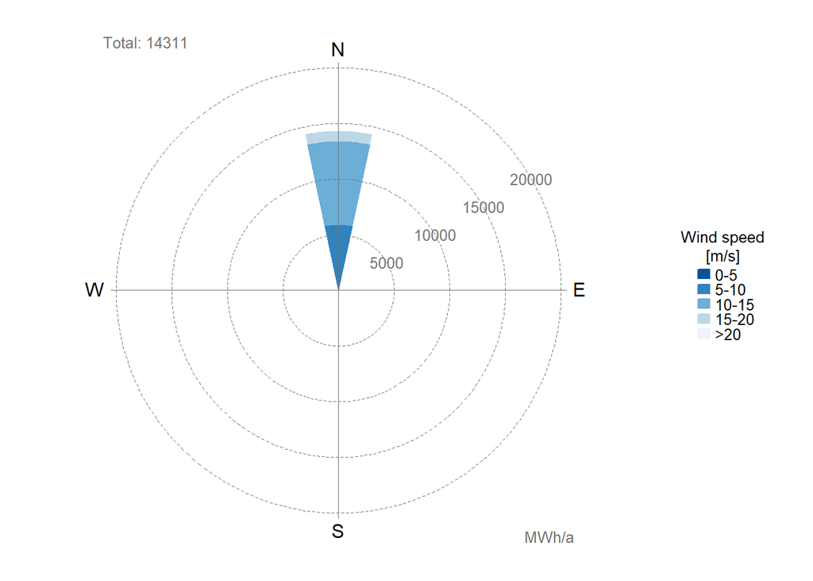

```r
capacity_6_hhmin <- aep_6_hhmin$capacity
AEP_Plot_6_hhmin <- plot(aep_6_hhmin)
```

```r
# calculate annual energy production with maximum hub height
aep_6_hhmax <- aep(profile = pf, pc = pc_6, hub.h = hh6_max)
```

```
##
##  Annual energy production
##
##       wind speed operation   total     0-5    5-10   10-15   15-20     >20
##            [m/s]     [h/a] [MWh/a] [MWh/a] [MWh/a] [MWh/a] [MWh/a] [MWh/a]
## N          9.092      8760   15767     129    5364    8601    1605      68
## NNE
## ENE
## E
## ESE
## SSE
## S
## SSW
## WSW
## W
## WNW
## NNW
## total      9.092      8760   15767     129    5364    8601    1605      68
##
## capacity factor: 0.585
##
## call: aep(profile=pf, pc=pc_6, hub.h=119, rho=1.225, avail=1, bins=c(0, 5, 10, 15, 20), sectoral=FALSE, digits=c(3, 0, 0, 3), print=TRUE)
```

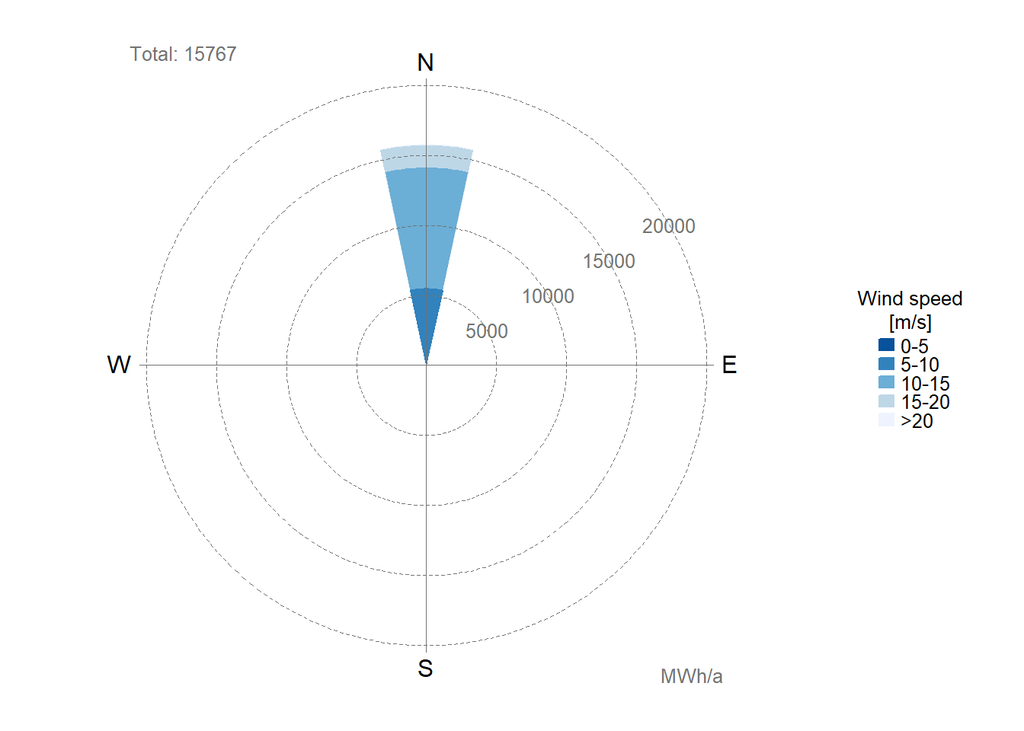

```r
capacity_6_hhmax <- aep_6_hhmax$capacity
AEP_Plot_6_hhmax <- plot(aep_6_hhmax)
```

```r
# plot energy production over typical day
```

#### Leitwind LTW101

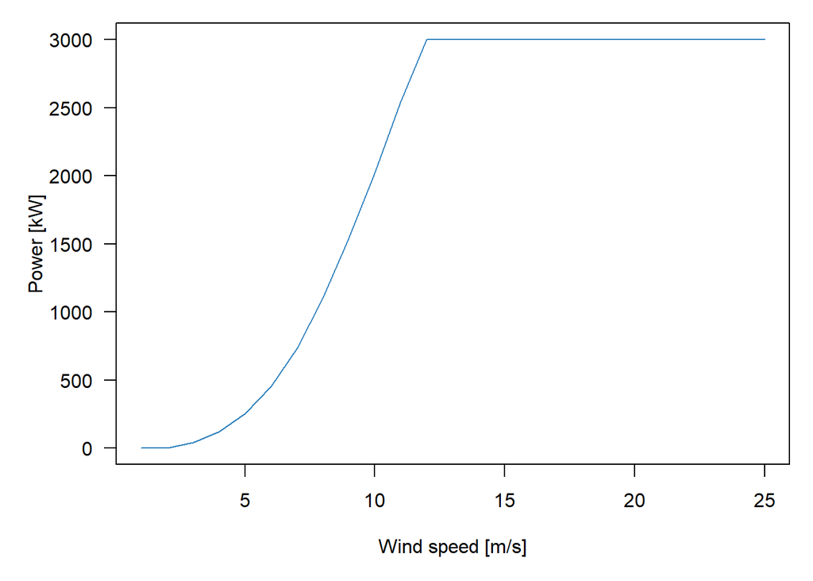

```r
# Power curve
pc_7 <- pc(Power_Curves$PC_File[7])
plot(pc_7, cp=TRUE, ct=TRUE)
```

```r
# Hub Height min & max
hh7_min <- Power_Curves$HH_min_m[7]
hh7_max <- Power_Curves$HH_max_m[7]

# calculate annual energy production with minimum hub height
aep_7_hhmin <- aep(profile = pf, pc = pc_7, hub.h = hh7_min)
```

```
##
##  Annual energy production
##
##       wind speed operation   total     0-5    5-10   10-15   15-20     >20
##            [m/s]     [h/a] [MWh/a] [MWh/a] [MWh/a] [MWh/a] [MWh/a] [MWh/a]
## N          8.692      8760   12982     141    4454    7244    1113      31
## NNE
## ENE
## E
## ESE
## SSE
## S
## SSW
## WSW
## W
## WNW
## NNW
## total      8.692      8760   12982     141    4454    7244    1113      31
##
## capacity factor: 0.494
##
## call: aep(profile=pf, pc=pc_7, hub.h=95, rho=1.225, avail=1, bins=c(0, 5, 10, 15, 20), sectoral=FALSE, digits=c(3, 0, 0, 3), print=TRUE)
```

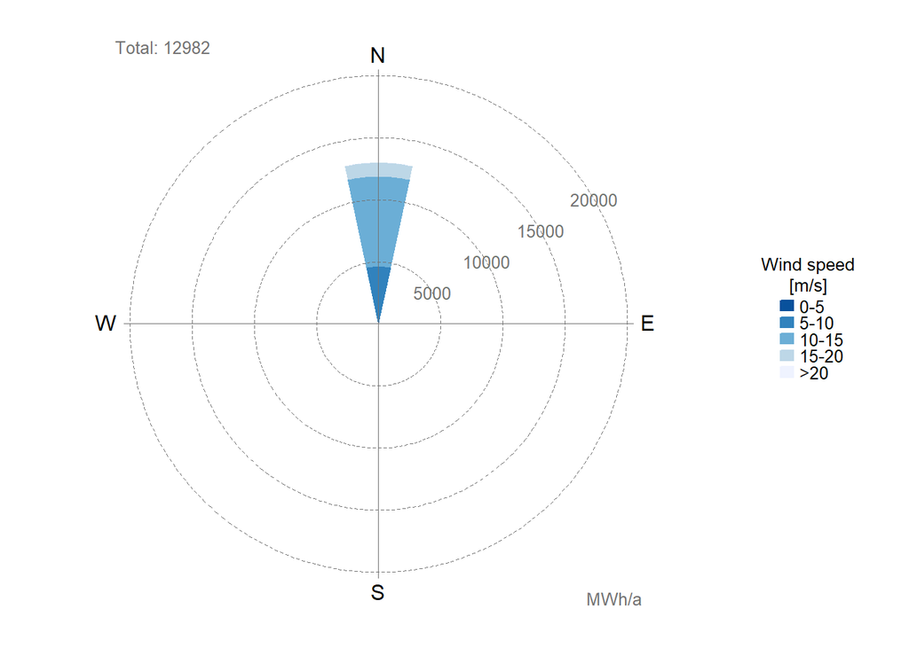

```r
capacity_7_hhmin <- aep_7_hhmin$capacity
AEP_Plot_7_hhmin <- plot(aep_7_hhmin)
```

```r
# calculate annual energy production with maximum hub height
aep_7_hhmax <- aep(profile = pf, pc = pc_7, hub.h = hh7_max)
```

```
##
##  Annual energy production
##
##       wind speed operation   total     0-5    5-10   10-15   15-20     >20
##            [m/s]     [h/a] [MWh/a] [MWh/a] [MWh/a] [MWh/a] [MWh/a] [MWh/a]
## N          9.433      8760   14677     116    4088    8357    2001     116
## NNE
## ENE
## E
## ESE
## SSE
## S
## SSW
## WSW
## W
## WNW
## NNW
## total      9.433      8760   14677     116    4088    8357    2001     116
##
## capacity factor: 0.558
##
## call: aep(profile=pf, pc=pc_7, hub.h=143, rho=1.225, avail=1, bins=c(0, 5, 10, 15, 20), sectoral=FALSE, digits=c(3, 0, 0, 3), print=TRUE)
```

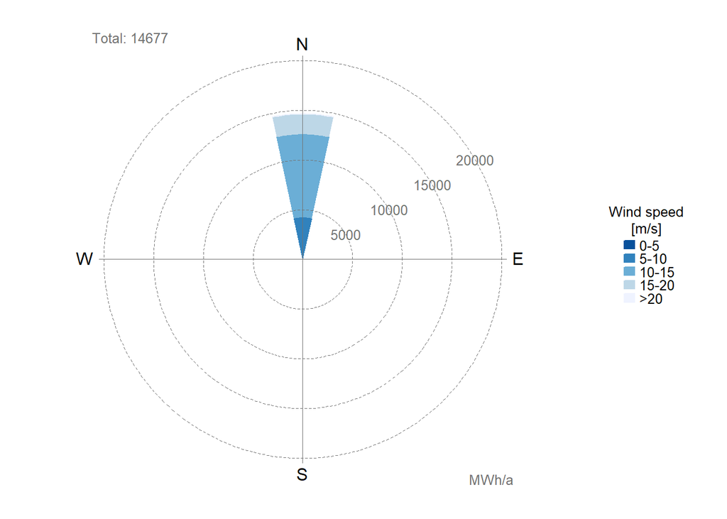

```r
capacity_7_hhmax <- aep_7_hhmax$capacity
AEP_Plot_7_hhmax <- plot(aep_7_hhmax)
```

```r
# plot energy production over typical day
```

#### Repower 5M

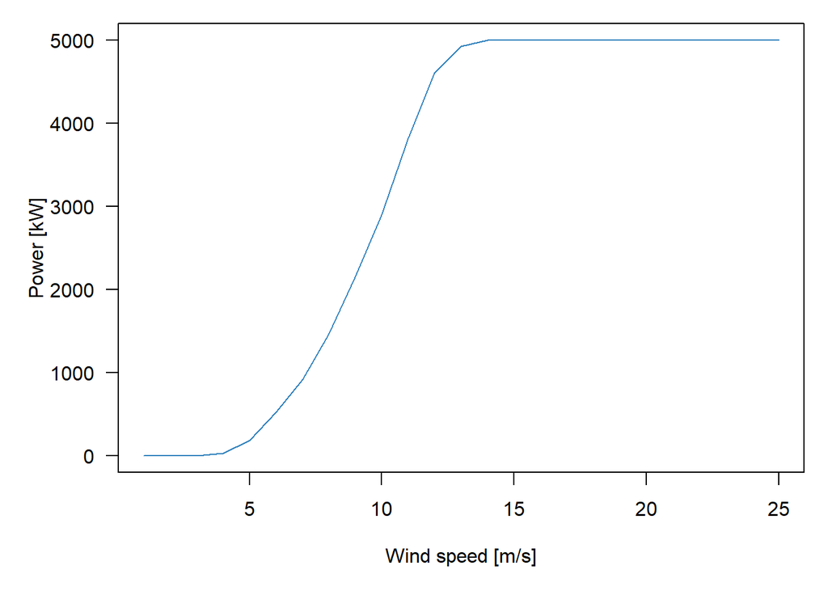

```r
# Power curve
pc_8 <- pc(Power_Curves$PC_File[8])
plot(pc_8, cp=TRUE, ct=TRUE)
```

```r
# Hub Height min & max
hh8_min <- Power_Curves$HH_min_m[8]
hh8_max <- Power_Curves$HH_max_m[8]

# calculate annual energy production with minimum hub height
aep_8_hhmin <- aep(profile = pf, pc = pc_8, hub.h = hh8_min)
```

```
##
##  Annual energy production
##
##       wind speed operation   total     0-5    5-10   10-15   15-20     >20
##            [m/s]     [h/a] [MWh/a] [MWh/a] [MWh/a] [MWh/a] [MWh/a] [MWh/a]
## N          8.692      8760   19183      53    5926   11298    1855      51
## NNE
## ENE
## E
## ESE
## SSE
## S
## SSW
## WSW
## W
## WNW
## NNW
## total      8.692      8760   19183      53    5926   11298    1855      51
##
## capacity factor: 0.438
##
## call: aep(profile=pf, pc=pc_8, hub.h=95, rho=1.225, avail=1, bins=c(0, 5, 10, 15, 20), sectoral=FALSE, digits=c(3, 0, 0, 3), print=TRUE)
```

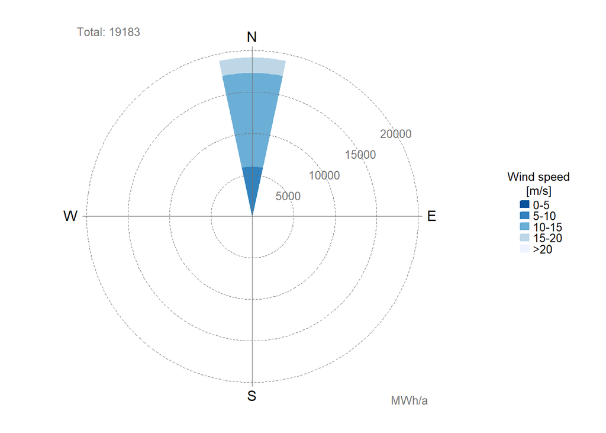

```r
capacity_8_hhmin <- aep_8_hhmin$capacity
AEP_Plot_8_hhmin <- plot(aep_8_hhmin)
```

```r
# calculate annual energy production with maximum hub height
aep_8_hhmax <- aep(profile = pf, pc = pc_8, hub.h = hh8_max)
```

```
##
##  Annual energy production
##
##       wind speed operation   total     0-5    5-10   10-15   15-20     >20
##            [m/s]     [h/a] [MWh/a] [MWh/a] [MWh/a] [MWh/a] [MWh/a] [MWh/a]
## N          9.062      8760   20688      48    5701   12286    2548     105
## NNE
## ENE
## E
## ESE
## SSE
## S
## SSW
## WSW
## W
## WNW
## NNW
## total      9.062      8760   20688      48    5701   12286    2548     105
##
## capacity factor: 0.472
##
## call: aep(profile=pf, pc=pc_8, hub.h=117, rho=1.225, avail=1, bins=c(0, 5, 10, 15, 20), sectoral=FALSE, digits=c(3, 0, 0, 3), print=TRUE)
```

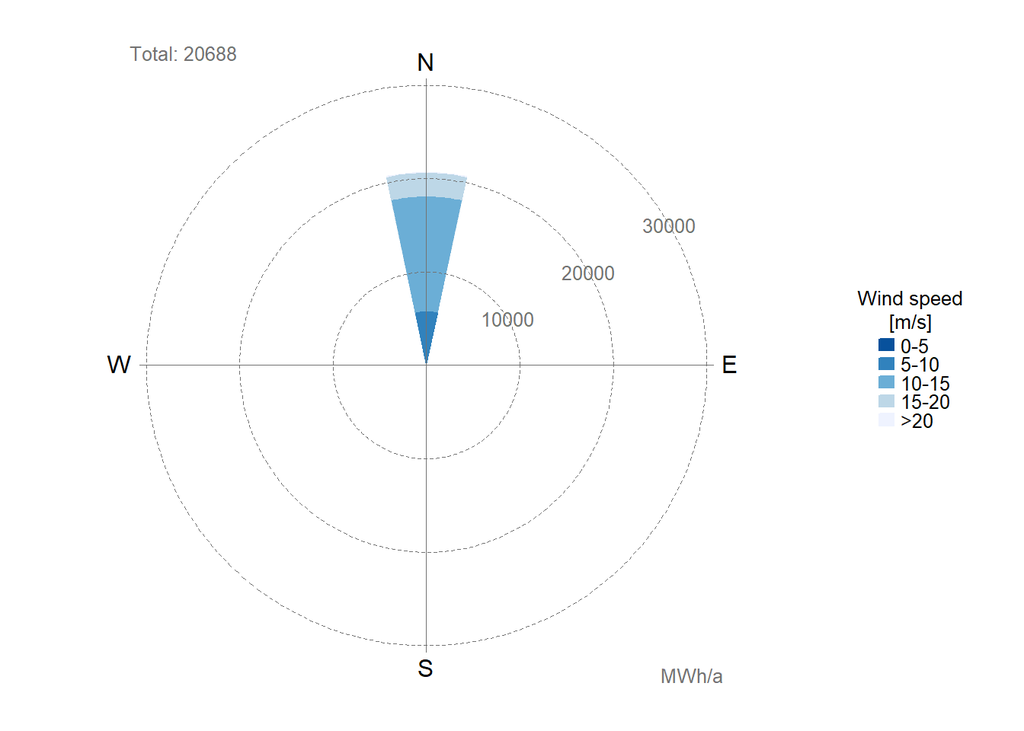

```r
capacity_8_hhmax <- aep_8_hhmax$capacity
AEP_Plot_8_hhmax <- plot(aep_8_hhmax)
```

```r
# plot energy production over typical day
```